# How Can a Wellness Technology Company Play It Smart?

Nipurn

2022-12-14

## Introduction and background

[figure not shown]

- For this case study, we are tasked to assist the marketing team at Bellabeat, a high-tech manufacturer of health-focused products for women.
- Urška Sršen, cofounder and Chief Creative Officer of Bellabeat, believes that analyzing smart device fitness data could help unlock new growth opportunities for the company.
- We have been asked to focus on one of Bellabeat’s products and analyze smart device data to gain insight into how consumers are using their smart devices.
- The insights you discover will then help guide marketing strategy for the company.
- We will present our analysis to the Bellabeat executive team along with our high-level recommendations for Bellabeat’s marketing strategy.

## Phase 1 - Ask

**Business Task** - Identify trends in usage of smart devices to make recommendations to marketing team for growth opportunities.  
**Key Stakeholders** - Urška Sršen, Sando Mur and Bellabeat marketing analytics team

## Phase 3 - Process

### Setting up environment

```r
library(tidyverse)
library(janitor)
```

### Importing CSV files

```r
daily_activity <- read_csv("dailyActivity_merged.csv")
daily_calories <- read_csv("dailyCalories_merged.csv")
daily_intensities <- read_csv("dailyIntensities_merged.csv")
daily_steps <- read_csv("dailySteps_merged.csv")
glimpse(daily_activity)
```

```
## Rows: 940
## Columns: 15
## $ Id                       <dbl> 1503960366, 1503960366, 1503960366, 150396036…
## $ ActivityDate             <chr> "4/12/2016", "4/13/2016", "4/14/2016", "4/15/…
## $ TotalSteps               <dbl> 13162, 10735, 10460, 9762, 12669, 9705, 13019…
## $ TotalDistance            <dbl> 8.50, 6.97, 6.74, 6.28, 8.16, 6.48, 8.59, 9.8…
## $ TrackerDistance          <dbl> 8.50, 6.97, 6.74, 6.28, 8.16, 6.48, 8.59, 9.8…
## $ LoggedActivitiesDistance <dbl> 0, 0, 0, 0, 0, 0, 0, 0, 0, 0, 0, 0, 0, 0, 0, …
## $ VeryActiveDistance       <dbl> 1.88, 1.57, 2.44, 2.14, 2.71, 3.19, 3.25, 3.5…
## $ ModeratelyActiveDistance <dbl> 0.55, 0.69, 0.40, 1.26, 0.41, 0.78, 0.64, 1.3…
## $ LightActiveDistance      <dbl> 6.06, 4.71, 3.91, 2.83, 5.04, 2.51, 4.71, 5.0…
## $ SedentaryActiveDistance  <dbl> 0, 0, 0, 0, 0, 0, 0, 0, 0, 0, 0, 0, 0, 0, 0, …
## $ VeryActiveMinutes        <dbl> 25, 21, 30, 29, 36, 38, 42, 50, 28, 19, 66, 4…
## $ FairlyActiveMinutes      <dbl> 13, 19, 11, 34, 10, 20, 16, 31, 12, 8, 27, 21…
## $ LightlyActiveMinutes     <dbl> 328, 217, 181, 209, 221, 164, 233, 264, 205, …
## $ SedentaryMinutes         <dbl> 728, 776, 1218, 726, 773, 539, 1149, 775, 818…
## $ Calories                 <dbl> 1985, 1797, 1776, 1745, 1863, 1728, 1921, 203…
```

```r
glimpse(daily_calories)
```

```
## Rows: 940
## Columns: 3
## $ Id          <dbl> 1503960366, 1503960366, 1503960366, 1503960366, 1503960366…
## $ ActivityDay <chr> "4/12/2016", "4/13/2016", "4/14/2016", "4/15/2016", "4/16/…
## $ Calories    <dbl> 1985, 1797, 1776, 1745, 1863, 1728, 1921, 2035, 1786, 1775…
```

```r
glimpse(daily_intensities)
```

```
## Rows: 940
## Columns: 10
## $ Id                       <dbl> 1503960366, 1503960366, 1503960366, 150396036…
## $ ActivityDay              <chr> "4/12/2016", "4/13/2016", "4/14/2016", "4/15/…
## $ SedentaryMinutes         <dbl> 728, 776, 1218, 726, 773, 539, 1149, 775, 818…
## $ LightlyActiveMinutes     <dbl> 328, 217, 181, 209, 221, 164, 233, 264, 205, …
## $ FairlyActiveMinutes      <dbl> 13, 19, 11, 34, 10, 20, 16, 31, 12, 8, 27, 21…
## $ VeryActiveMinutes        <dbl> 25, 21, 30, 29, 36, 38, 42, 50, 28, 19, 66, 4…
## $ SedentaryActiveDistance  <dbl> 0, 0, 0, 0, 0, 0, 0, 0, 0, 0, 0, 0, 0, 0, 0, …
## $ LightActiveDistance      <dbl> 6.06, 4.71, 3.91, 2.83, 5.04, 2.51, 4.71, 5.0…
## $ ModeratelyActiveDistance <dbl> 0.55, 0.69, 0.40, 1.26, 0.41, 0.78, 0.64, 1.3…
## $ VeryActiveDistance       <dbl> 1.88, 1.57, 2.44, 2.14, 2.71, 3.19, 3.25, 3.5…
```

```r
glimpse(daily_steps)
```

```
## Rows: 940
## Columns: 3
## $ Id          <dbl> 1503960366, 1503960366, 1503960366, 1503960366, 1503960366…
## $ ActivityDay <chr> "4/12/2016", "4/13/2016", "4/14/2016", "4/15/2016", "4/16/…
## $ StepTotal   <dbl> 13162, 10735, 10460, 9762, 12669, 9705, 13019, 15506, 1054…
```

- At first glance, it seems daily_activity is a consolidated dataframe of daily_calories, daily_intensities and daily_steps. Let us verify.

```r
dailyact_calories <- daily_activity %>%
  rename(ActivityDay = ActivityDate) %>%
   select(Id, ActivityDay, Calories)

data_common1 <- inner_join(dailyact_calories, daily_calories)
glimpse(data_common1)
```

```
## Rows: 940
## Columns: 3
## $ Id          <dbl> 1503960366, 1503960366, 1503960366, 1503960366, 1503960366…
## $ ActivityDay <chr> "4/12/2016", "4/13/2016", "4/14/2016", "4/15/2016", "4/16/…
## $ Calories    <dbl> 1985, 1797, 1776, 1745, 1863, 1728, 1921, 2035, 1786, 1775…
```

```r
dailyact_intensities <- daily_activity %>%
    rename(ActivityDay = ActivityDate) %>%
    select(Id, ActivityDay, SedentaryMinutes, LightlyActiveMinutes, FairlyActiveMinutes, VeryActiveMinutes, SedentaryActiveDistance, LightActiveDistance, ModeratelyActiveDistance, VeryActiveDistance)
data_common2 <- inner_join(dailyact_intensities, daily_intensities)
```

[output not shown]

```r
glimpse(data_common2)
```

```
## Rows: 940
## Columns: 10
## $ Id                       <dbl> 1503960366, 1503960366, 1503960366, 150396036…
## $ ActivityDay              <chr> "4/12/2016", "4/13/2016", "4/14/2016", "4/15/…
## $ SedentaryMinutes         <dbl> 728, 776, 1218, 726, 773, 539, 1149, 775, 818…
## $ LightlyActiveMinutes     <dbl> 328, 217, 181, 209, 221, 164, 233, 264, 205, …
## $ FairlyActiveMinutes      <dbl> 13, 19, 11, 34, 10, 20, 16, 31, 12, 8, 27, 21…
## $ VeryActiveMinutes        <dbl> 25, 21, 30, 29, 36, 38, 42, 50, 28, 19, 66, 4…
## $ SedentaryActiveDistance  <dbl> 0, 0, 0, 0, 0, 0, 0, 0, 0, 0, 0, 0, 0, 0, 0, …
## $ LightActiveDistance      <dbl> 6.06, 4.71, 3.91, 2.83, 5.04, 2.51, 4.71, 5.0…
## $ ModeratelyActiveDistance <dbl> 0.55, 0.69, 0.40, 1.26, 0.41, 0.78, 0.64, 1.3…
## $ VeryActiveDistance       <dbl> 1.88, 1.57, 2.44, 2.14, 2.71, 3.19, 3.25, 3.5…
```

```r
dailyact_steps <- daily_activity %>%
      rename(ActivityDay = ActivityDate) %>%
  select(Id, ActivityDay, TotalSteps)
data_common3 <- inner_join(dailyact_steps, daily_steps)
glimpse(data_common3)
```

```
## Rows: 940
## Columns: 4
## $ Id          <dbl> 1503960366, 1503960366, 1503960366, 1503960366, 1503960366…
## $ ActivityDay <chr> "4/12/2016", "4/13/2016", "4/14/2016", "4/15/2016", "4/16/…
## $ TotalSteps  <dbl> 13162, 10735, 10460, 9762, 12669, 9705, 13019, 15506, 1054…
## $ StepTotal   <dbl> 13162, 10735, 10460, 9762, 12669, 9705, 13019, 15506, 1054…
```

- It can be safely concluded that daily_activity is a consolidated dataframe, comprising data from daily_calories, daily_intensities and daily_steps dataframes. We can remove the latter 3 dataframes.

```r
# Importing other dataframes
hourly_calories <- read_csv("hourlyCalories_merged.csv")
hourly_intensities <- read_csv("hourlyIntensities_merged.csv")
hourly_steps <- read_csv("hourlySteps_merged.csv")
sleep_day <- read_csv("sleepDay_merged.csv")
weight_log <- read_csv("weightLogInfo_merged.csv")
glimpse(hourly_calories)
```

```
## Rows: 22,099
## Columns: 3
## $ Id           <dbl> 1503960366, 1503960366, 1503960366, 1503960366, 150396036…
## $ ActivityHour <chr> "4/12/2016 12:00:00 AM", "4/12/2016 1:00:00 AM", "4/12/20…
## $ Calories     <dbl> 81, 61, 59, 47, 48, 48, 48, 47, 68, 141, 99, 76, 73, 66, …
```

```r
glimpse(hourly_intensities)
```

```
## Rows: 22,099
## Columns: 4
## $ Id               <dbl> 1503960366, 1503960366, 1503960366, 1503960366, 15039…
## $ ActivityHour     <chr> "4/12/2016 12:00:00 AM", "4/12/2016 1:00:00 AM", "4/1…
## $ TotalIntensity   <dbl> 20, 8, 7, 0, 0, 0, 0, 0, 13, 30, 29, 12, 11, 6, 36, 5…
## $ AverageIntensity <dbl> 0.333333, 0.133333, 0.116667, 0.000000, 0.000000, 0.0…
```

```r
glimpse(hourly_steps)
```

```
## Rows: 22,099
## Columns: 3
## $ Id           <dbl> 1503960366, 1503960366, 1503960366, 1503960366, 150396036…
## $ ActivityHour <chr> "4/12/2016 12:00:00 AM", "4/12/2016 1:00:00 AM", "4/12/20…
## $ StepTotal    <dbl> 373, 160, 151, 0, 0, 0, 0, 0, 250, 1864, 676, 360, 253, 2…
```

```r
glimpse(sleep_day)
```

```
## Rows: 413
## Columns: 5
## $ Id                 <dbl> 1503960366, 1503960366, 1503960366, 1503960366, 150…
## $ SleepDay           <chr> "4/12/2016 12:00:00 AM", "4/13/2016 12:00:00 AM", "…
## $ TotalSleepRecords  <dbl> 1, 2, 1, 2, 1, 1, 1, 1, 1, 1, 1, 1, 1, 1, 1, 1, 1, …
## $ TotalMinutesAsleep <dbl> 327, 384, 412, 340, 700, 304, 360, 325, 361, 430, 2…
## $ TotalTimeInBed     <dbl> 346, 407, 442, 367, 712, 320, 377, 364, 384, 449, 3…
```

```r
glimpse(weight_log)
```

```
## Rows: 67
## Columns: 8
## $ Id             <dbl> 1503960366, 1503960366, 1927972279, 2873212765, 2873212…
## $ Date           <chr> "5/2/2016 11:59:59 PM", "5/3/2016 11:59:59 PM", "4/13/2…
## $ WeightKg       <dbl> 52.6, 52.6, 133.5, 56.7, 57.3, 72.4, 72.3, 69.7, 70.3, …
## $ WeightPounds   <dbl> 115.9631, 115.9631, 294.3171, 125.0021, 126.3249, 159.6…
## $ Fat            <dbl> 22, NA, NA, NA, NA, 25, NA, NA, NA, NA, NA, NA, NA, NA,…
## $ BMI            <dbl> 22.65, 22.65, 47.54, 21.45, 21.69, 27.45, 27.38, 27.25,…
## $ IsManualReport <lgl> TRUE, TRUE, FALSE, TRUE, TRUE, TRUE, TRUE, TRUE, TRUE, …
## $ LogId          <dbl> 1.462234e+12, 1.462320e+12, 1.460510e+12, 1.461283e+12,…
```

### Cleaning Data

#### Check for Null values

```r
sum(is.na(daily_activity))
```

```
## [1] 0
```

```r
sum(is.na(hourly_calories))
```

```
## [1] 0
```

```r
sum(is.na(hourly_intensities))
```

```
## [1] 0
```

```r
sum(is.na(hourly_steps))
```

```
## [1] 0
```

```r
sum(is.na(sleep_day))
```

```
## [1] 0
```

```r
sum(is.na(weight_log))
```

```
## [1] 65
```

- The ‘Fat’ column in weight_log has a lot of Null values.

#### Check for duplicate values

```r
sum(duplicated(daily_activity))
```

```
## [1] 0
```

```r
sum(duplicated(hourly_calories))
```

```
## [1] 0
```

```r
sum(duplicated(hourly_intensities))
```

```
## [1] 0
```

```r
sum(duplicated(hourly_steps))
```

```
## [1] 0
```

```r
sum(duplicated(sleep_day))
```

```
## [1] 3
```

```r
sum(duplicated(weight_log))
```

```
## [1] 0
```

```r
#Remove duplicate values from sleep_day dataframe
sleep_day <- sleep_day %>%
  distinct()
```

#### Standardizing column names

```r
#Cleaning dataframe column names

daily_activity <- daily_activity %>%
  clean_names() %>%
  rename(date = activity_date)

hourly_calories <- hourly_calories %>%
  clean_names() %>%
  rename(date = activity_hour)

hourly_intensities <- hourly_intensities %>%
  clean_names() %>%
  rename(date = activity_hour)

hourly_steps <- hourly_steps %>%
  clean_names() %>%
  rename(date = activity_hour)

sleep_day <- sleep_day %>%
  clean_names() %>%
  rename(date = sleep_day)

weight_log <- clean_names(weight_log)
```

#### Fixing datatypes of columns

```r
# Changing datatype of date columns

daily_activity <- daily_activity %>%
  mutate(date = as.Date(date, "%m/%d/%Y"))

## hourly_calories dataframe
#format date column from char to date-time
hourly_calories$date = as.POSIXct(hourly_calories$date, format = "%m/%d/%Y %I:%M:%S %p")

#create new column named 'time' extracting time from date column
hourly_calories$time <- format(hourly_calories$date, format = "%H:%M:%S")


## hourly_intensities dataframe
#format date column from char to date-time
hourly_intensities$date = as.POSIXct(hourly_intensities$date, format = "%m/%d/%Y %I:%M:%S %p")

#create new column named 'time' extracting time from date column
hourly_intensities$time <- format(hourly_intensities$date, format = "%H:%M:%S")


## hourly_steps dataframe
#format date column from char to date-time
hourly_steps$date = as.POSIXct(hourly_steps$date, format = "%m/%d/%Y %I:%M:%S %p")

#create new column named 'time' extracting time from date column
hourly_steps$time <- format(hourly_steps$date, format = "%H:%M:%S")


## sleep_day dataframe
sleep_day <- sleep_day %>%
  mutate(date = as.Date(date, format="%m/%d/%Y"))


## weight_log dataframe
weight_log <- weight_log %>%
  mutate(date = as.Date(date, format="%m/%d/%Y"))
```

#### Final check for dataframes

```r
head(daily_activity)
```

```
## # A tibble: 6 × 15
##           id date       total_…¹ total…² track…³ logge…⁴ very_…⁵ moder…⁶ light…⁷
##        <dbl> <date>        <dbl>   <dbl>   <dbl>   <dbl>   <dbl>   <dbl>   <dbl>
## 1 1503960366 2016-04-12    13162    8.5     8.5        0    1.88   0.550    6.06
## 2 1503960366 2016-04-13    10735    6.97    6.97       0    1.57   0.690    4.71
## 3 1503960366 2016-04-14    10460    6.74    6.74       0    2.44   0.400    3.91
## 4 1503960366 2016-04-15     9762    6.28    6.28       0    2.14   1.26     2.83
## 5 1503960366 2016-04-16    12669    8.16    8.16       0    2.71   0.410    5.04
## 6 1503960366 2016-04-17     9705    6.48    6.48       0    3.19   0.780    2.51
## # … with 6 more variables: sedentary_active_distance <dbl>,
## #   very_active_minutes <dbl>, fairly_active_minutes <dbl>,
## #   lightly_active_minutes <dbl>, sedentary_minutes <dbl>, calories <dbl>, and
## #   abbreviated variable names ¹total_steps, ²total_distance,
## #   ³tracker_distance, ⁴logged_activities_distance, ⁵very_active_distance,
## #   ⁶moderately_active_distance, ⁷light_active_distance
```

```r
head(hourly_calories)
```

```
## # A tibble: 6 × 4
##           id date                calories time
##        <dbl> <dttm>                 <dbl> <chr>
## 1 1503960366 2016-04-12 00:00:00       81 00:00:00
## 2 1503960366 2016-04-12 01:00:00       61 01:00:00
## 3 1503960366 2016-04-12 02:00:00       59 02:00:00
## 4 1503960366 2016-04-12 03:00:00       47 03:00:00
## 5 1503960366 2016-04-12 04:00:00       48 04:00:00
## 6 1503960366 2016-04-12 05:00:00       48 05:00:00
```

```r
head(hourly_intensities)
```

```
## # A tibble: 6 × 5
##           id date                total_intensity average_intensity time
##        <dbl> <dttm>                        <dbl>             <dbl> <chr>
## 1 1503960366 2016-04-12 00:00:00              20             0.333 00:00:00
## 2 1503960366 2016-04-12 01:00:00               8             0.133 01:00:00
## 3 1503960366 2016-04-12 02:00:00               7             0.117 02:00:00
## 4 1503960366 2016-04-12 03:00:00               0             0     03:00:00
## 5 1503960366 2016-04-12 04:00:00               0             0     04:00:00
## 6 1503960366 2016-04-12 05:00:00               0             0     05:00:00
```

```r
head(hourly_steps)
```

```
## # A tibble: 6 × 4
##           id date                step_total time
##        <dbl> <dttm>                   <dbl> <chr>
## 1 1503960366 2016-04-12 00:00:00        373 00:00:00
## 2 1503960366 2016-04-12 01:00:00        160 01:00:00
## 3 1503960366 2016-04-12 02:00:00        151 02:00:00
## 4 1503960366 2016-04-12 03:00:00          0 03:00:00
## 5 1503960366 2016-04-12 04:00:00          0 04:00:00
## 6 1503960366 2016-04-12 05:00:00          0 05:00:00
```

```r
head(sleep_day)
```

```
## # A tibble: 6 × 5
##           id date       total_sleep_records total_minutes_asleep total_time_in…¹
##        <dbl> <date>                   <dbl>                <dbl>           <dbl>
## 1 1503960366 2016-04-12                   1                  327             346
## 2 1503960366 2016-04-13                   2                  384             407
## 3 1503960366 2016-04-15                   1                  412             442
## 4 1503960366 2016-04-16                   2                  340             367
## 5 1503960366 2016-04-17                   1                  700             712
## 6 1503960366 2016-04-19                   1                  304             320
## # … with abbreviated variable name ¹total_time_in_bed
```

```r
head(weight_log)
```

```
## # A tibble: 6 × 8
##           id date       weight_kg weight_pounds   fat   bmi is_manual_…¹  log_id
##        <dbl> <date>         <dbl>         <dbl> <dbl> <dbl> <lgl>          <dbl>
## 1 1503960366 2016-05-02      52.6          116.    22  22.6 TRUE         1.46e12
## 2 1503960366 2016-05-03      52.6          116.    NA  22.6 TRUE         1.46e12
## 3 1927972279 2016-04-13     134.           294.    NA  47.5 FALSE        1.46e12
## 4 2873212765 2016-04-21      56.7          125.    NA  21.5 TRUE         1.46e12
## 5 2873212765 2016-05-12      57.3          126.    NA  21.7 TRUE         1.46e12
## 6 4319703577 2016-04-17      72.4          160.    25  27.5 TRUE         1.46e12
## # … with abbreviated variable name ¹is_manual_report
```

### Guiding Questions

**What tools are you choosing and why?**  
I’m choosing to work with R, as it is accessible to import, clean, process, analyze and visualize dataframes.  
**What steps have you taken to ensure that your data is clean?**  
I have checked for null data, duplicate entries, formatted column names and fixed datatypes for date columns.  
**How can you verify that your data is clean and ready to analyze?**  
I have double-checked the data post cleaning.  
**Have you documented your cleaning process so you can review and share those results?**  
I have documented the cleaning process for review.

## Phase 4 - Analyze

### Quick Summary Statistics

```r
# Analyzing Participants
n_distinct(daily_activity$id)
```

```
## [1] 33
```

```r
n_distinct(hourly_calories$id)
```

```
## [1] 33
```

```r
n_distinct(hourly_intensities$id)
```

```
## [1] 33
```

```r
n_distinct(hourly_steps$id)
```

```
## [1] 33
```

```r
n_distinct(sleep_day$id)
```

```
## [1] 24
```

```r
n_distinct(weight_log$id)
```

```
## [1] 8
```

- sleep_day dataframe has data for 24 and weight_log has data for 8 participants, while rest have data for 33 participants.

```r
# Analyzing no. of observations
nrow(daily_activity)
```

```
## [1] 940
```

```r
nrow(hourly_calories)
```

```
## [1] 22099
```

```r
nrow(hourly_intensities)
```

```
## [1] 22099
```

```r
nrow(hourly_steps)
```

```
## [1] 22099
```

```r
nrow(sleep_day)
```

```
## [1] 410
```

```r
nrow(weight_log)
```

```
## [1] 67
```

```r
# Summary Statistics
daily_activity %>%
  summary()
```

```
##        id                 date             total_steps    total_distance
##  Min.   :1.504e+09   Min.   :2016-04-12   Min.   :    0   Min.   : 0.000
##  1st Qu.:2.320e+09   1st Qu.:2016-04-19   1st Qu.: 3790   1st Qu.: 2.620
##  Median :4.445e+09   Median :2016-04-26   Median : 7406   Median : 5.245
##  Mean   :4.855e+09   Mean   :2016-04-26   Mean   : 7638   Mean   : 5.490
##  3rd Qu.:6.962e+09   3rd Qu.:2016-05-04   3rd Qu.:10727   3rd Qu.: 7.713
##  Max.   :8.878e+09   Max.   :2016-05-12   Max.   :36019   Max.   :28.030
##  tracker_distance logged_activities_distance very_active_distance
##  Min.   : 0.000   Min.   :0.0000             Min.   : 0.000
##  1st Qu.: 2.620   1st Qu.:0.0000             1st Qu.: 0.000
##  Median : 5.245   Median :0.0000             Median : 0.210
##  Mean   : 5.475   Mean   :0.1082             Mean   : 1.503
##  3rd Qu.: 7.710   3rd Qu.:0.0000             3rd Qu.: 2.053
##  Max.   :28.030   Max.   :4.9421             Max.   :21.920
##  moderately_active_distance light_active_distance sedentary_active_distance
##  Min.   :0.0000             Min.   : 0.000        Min.   :0.000000
##  1st Qu.:0.0000             1st Qu.: 1.945        1st Qu.:0.000000
##  Median :0.2400             Median : 3.365        Median :0.000000
##  Mean   :0.5675             Mean   : 3.341        Mean   :0.001606
##  3rd Qu.:0.8000             3rd Qu.: 4.782        3rd Qu.:0.000000
##  Max.   :6.4800             Max.   :10.710        Max.   :0.110000
##  very_active_minutes fairly_active_minutes lightly_active_minutes
##  Min.   :  0.00      Min.   :  0.00        Min.   :  0.0
##  1st Qu.:  0.00      1st Qu.:  0.00        1st Qu.:127.0
##  Median :  4.00      Median :  6.00        Median :199.0
##  Mean   : 21.16      Mean   : 13.56        Mean   :192.8
##  3rd Qu.: 32.00      3rd Qu.: 19.00        3rd Qu.:264.0
##  Max.   :210.00      Max.   :143.00        Max.   :518.0
##  sedentary_minutes    calories
##  Min.   :   0.0    Min.   :   0
##  1st Qu.: 729.8    1st Qu.:1828
##  Median :1057.5    Median :2134
##  Mean   : 991.2    Mean   :2304
##  3rd Qu.:1229.5    3rd Qu.:2793
##  Max.   :1440.0    Max.   :4900
```

```r
hourly_calories %>%
  summary()
```

```
##        id                 date                           calories
##  Min.   :1.504e+09   Min.   :2016-04-12 00:00:00.00   Min.   : 42.00
##  1st Qu.:2.320e+09   1st Qu.:2016-04-19 01:00:00.00   1st Qu.: 63.00
##  Median :4.445e+09   Median :2016-04-26 06:00:00.00   Median : 83.00
##  Mean   :4.848e+09   Mean   :2016-04-26 11:46:42.58   Mean   : 97.39
##  3rd Qu.:6.962e+09   3rd Qu.:2016-05-03 19:00:00.00   3rd Qu.:108.00
##  Max.   :8.878e+09   Max.   :2016-05-12 15:00:00.00   Max.   :948.00
##      time
##  Length:22099
##  Class :character
##  Mode  :character
##
##
##
```

```r
hourly_intensities %>%
  summary()
```

```
##        id                 date                        total_intensity
##  Min.   :1.504e+09   Min.   :2016-04-12 00:00:00.00   Min.   :  0.00
##  1st Qu.:2.320e+09   1st Qu.:2016-04-19 01:00:00.00   1st Qu.:  0.00
##  Median :4.445e+09   Median :2016-04-26 06:00:00.00   Median :  3.00
##  Mean   :4.848e+09   Mean   :2016-04-26 11:46:42.58   Mean   : 12.04
##  3rd Qu.:6.962e+09   3rd Qu.:2016-05-03 19:00:00.00   3rd Qu.: 16.00
##  Max.   :8.878e+09   Max.   :2016-05-12 15:00:00.00   Max.   :180.00
##  average_intensity     time
##  Min.   :0.0000    Length:22099
##  1st Qu.:0.0000    Class :character
##  Median :0.0500    Mode  :character
##  Mean   :0.2006
##  3rd Qu.:0.2667
##  Max.   :3.0000
```

```r
hourly_steps %>%
  summary()
```

```
##        id                 date                          step_total
##  Min.   :1.504e+09   Min.   :2016-04-12 00:00:00.00   Min.   :    0.0
##  1st Qu.:2.320e+09   1st Qu.:2016-04-19 01:00:00.00   1st Qu.:    0.0
##  Median :4.445e+09   Median :2016-04-26 06:00:00.00   Median :   40.0
##  Mean   :4.848e+09   Mean   :2016-04-26 11:46:42.58   Mean   :  320.2
##  3rd Qu.:6.962e+09   3rd Qu.:2016-05-03 19:00:00.00   3rd Qu.:  357.0
##  Max.   :8.878e+09   Max.   :2016-05-12 15:00:00.00   Max.   :10554.0
##      time
##  Length:22099
##  Class :character
##  Mode  :character
##
##
##
```

```r
sleep_day %>%
  summary()
```

```
##        id                 date            total_sleep_records
##  Min.   :1.504e+09   Min.   :2016-04-12   Min.   :1.00
##  1st Qu.:3.977e+09   1st Qu.:2016-04-19   1st Qu.:1.00
##  Median :4.703e+09   Median :2016-04-27   Median :1.00
##  Mean   :4.995e+09   Mean   :2016-04-26   Mean   :1.12
##  3rd Qu.:6.962e+09   3rd Qu.:2016-05-04   3rd Qu.:1.00
##  Max.   :8.792e+09   Max.   :2016-05-12   Max.   :3.00
##  total_minutes_asleep total_time_in_bed
##  Min.   : 58.0        Min.   : 61.0
##  1st Qu.:361.0        1st Qu.:403.8
##  Median :432.5        Median :463.0
##  Mean   :419.2        Mean   :458.5
##  3rd Qu.:490.0        3rd Qu.:526.0
##  Max.   :796.0        Max.   :961.0
```

```r
weight_log %>%
  summary()
```

```
##        id                 date              weight_kg      weight_pounds
##  Min.   :1.504e+09   Min.   :2016-04-12   Min.   : 52.60   Min.   :116.0
##  1st Qu.:6.962e+09   1st Qu.:2016-04-19   1st Qu.: 61.40   1st Qu.:135.4
##  Median :6.962e+09   Median :2016-04-27   Median : 62.50   Median :137.8
##  Mean   :7.009e+09   Mean   :2016-04-26   Mean   : 72.04   Mean   :158.8
##  3rd Qu.:8.878e+09   3rd Qu.:2016-05-04   3rd Qu.: 85.05   3rd Qu.:187.5
##  Max.   :8.878e+09   Max.   :2016-05-12   Max.   :133.50   Max.   :294.3
##
##       fat             bmi        is_manual_report     log_id
##  Min.   :22.00   Min.   :21.45   Mode :logical    Min.   :1.460e+12
##  1st Qu.:22.75   1st Qu.:23.96   FALSE:26         1st Qu.:1.461e+12
##  Median :23.50   Median :24.39   TRUE :41         Median :1.462e+12
##  Mean   :23.50   Mean   :25.19                    Mean   :1.462e+12
##  3rd Qu.:24.25   3rd Qu.:25.56                    3rd Qu.:1.462e+12
##  Max.   :25.00   Max.   :47.54                    Max.   :1.463e+12
##  NA's   :65
```

### Plotting Data

#### Relationship between Total steps and sedentary minutes

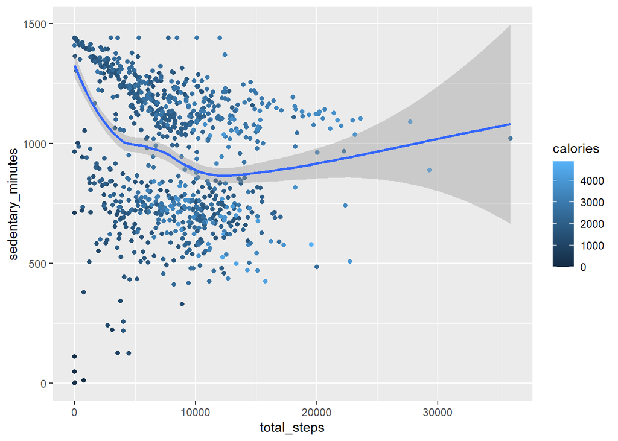

```r
ggplot(data=daily_activity) + geom_point(mapping=aes(x=total_steps, y=sedentary_minutes, color=calories)) +
  geom_smooth(mapping=aes(x=total_steps, y=sedentary_minutes))
```

#### Relationship between very active minutes & calories

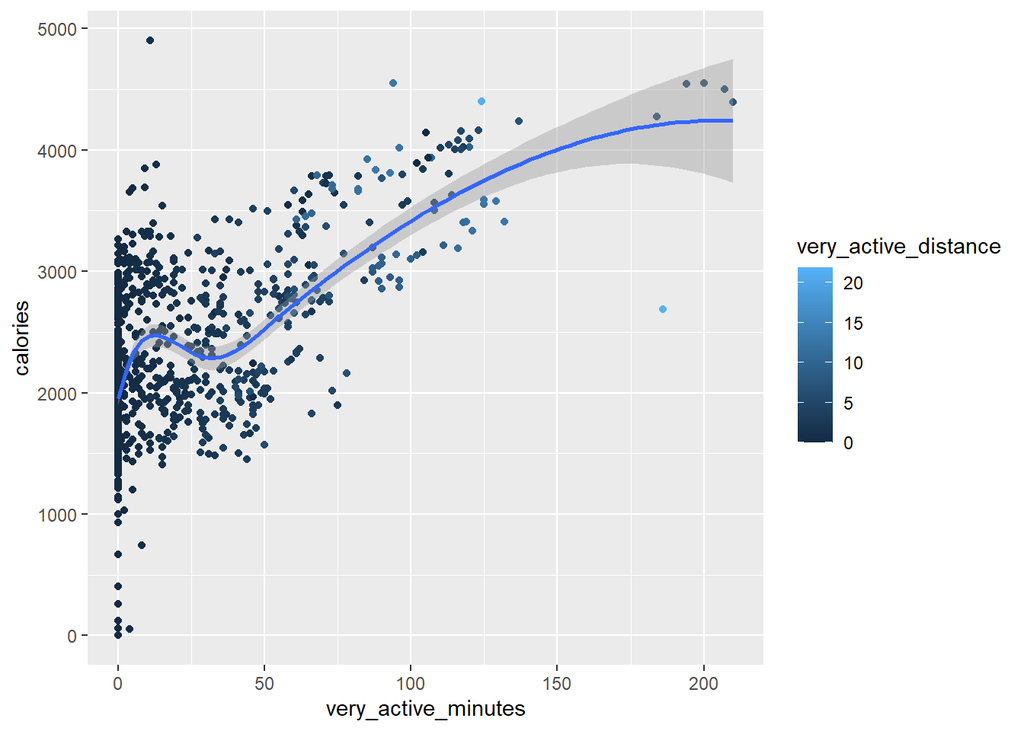

```r
ggplot(data=daily_activity) + geom_point(mapping=aes(x=very_active_minutes, y=calories, color=very_active_distance)) +
  geom_smooth(mapping=aes(x=very_active_minutes, y=calories))
```

**Observations:**

- A positive relation between very active minutes and calories burnt.

#### Average distribution of active minutes, by percentage

```r
total_sums <- daily_activity %>%
  summarize(total_sm = sum(sedentary_minutes), total_lam = sum(lightly_active_minutes), total_fam=sum(fairly_active_minutes), total_vam=sum(very_active_minutes))

total_tm <- total_sums %>%
  summarize(sum(total_sm, total_lam, total_fam, total_vam))

average_tm <- total_sums %>%
  summarize(avg_sm = (total_sm/total_tm)*100, avg_lam = (total_lam/total_tm)*100, avg_fam = (total_fam/total_tm)*100, avg_vam = (total_vam/total_tm)*100)

average_tm
```

```
## # A tibble: 1 × 4
##   avg_sm$sum(total_sm, total_lam, total_fam, total_vam…¹ avg_l…² avg_f…³ avg_v…⁴
##                                                    <dbl>   <dbl>   <dbl>   <dbl>
## 1                                                   81.3    15.8    1.11    1.74
## # … with abbreviated variable names
## #   ¹avg_sm$`sum(total_sm, total_lam, total_fam, total_vam)`,
## #   ²avg_lam$`sum(total_sm, total_lam, total_fam, total_vam)`,
## #   ³avg_fam$`sum(total_sm, total_lam, total_fam, total_vam)`,
## #   ⁴avg_vam$`sum(total_sm, total_lam, total_fam, total_vam)`
```

**Observations:**

- 81.3% is occupied by sedentary minutes.
- Only 1.74% of activity is occupied by very active minutes.

#### Relationship between total steps & calories

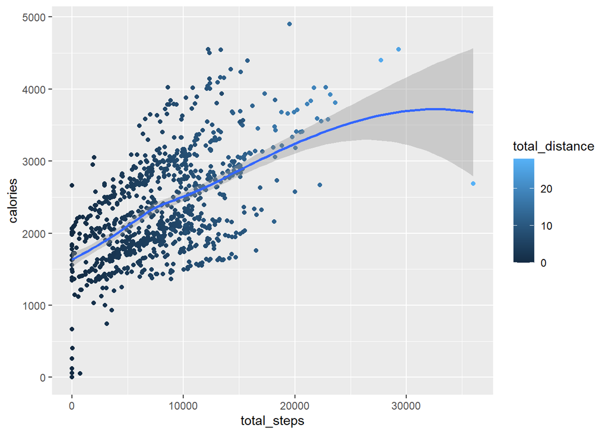

```r
ggplot(data=daily_activity) + geom_point(mapping=aes(x=total_steps, y=calories, color=total_distance)) +
  geom_smooth(mapping=aes(x=total_steps, y=calories))
```

**Observations:**

- A positive relationship between total steps and calories burnt.

#### Determining the time users were most active

```r
#Merging hourly datasets

hcal_mean <- hourly_calories %>%
  group_by(time) %>%
  summarize(mean_calories = mean(calories))
head(hcal_mean)
```

```
## # A tibble: 6 × 2
##   time     mean_calories
##   <chr>            <dbl>
## 1 00:00:00          71.8
## 2 01:00:00          70.2
## 3 02:00:00          69.2
## 4 03:00:00          67.5
## 5 04:00:00          68.3
## 6 05:00:00          81.7
```

```r
hint_mean <- hourly_intensities %>%
  group_by(time) %>%
  summarize(mean_intensity = mean(total_intensity))
head(hint_mean)
```

```
## # A tibble: 6 × 2
##   time     mean_intensity
##   <chr>             <dbl>
## 1 00:00:00          2.13
## 2 01:00:00          1.42
## 3 02:00:00          1.04
## 4 03:00:00          0.444
## 5 04:00:00          0.633
## 6 05:00:00          4.95
```

```r
hsteps_mean <- hourly_steps %>%
  group_by(time) %>%
  summarize(mean_steps = mean(step_total))
head(hsteps_mean)
```

```
## # A tibble: 6 × 2
##   time     mean_steps
##   <chr>         <dbl>
## 1 00:00:00      42.2
## 2 01:00:00      23.1
## 3 02:00:00      17.1
## 4 03:00:00       6.43
## 5 04:00:00      12.7
## 6 05:00:00      43.9
```

```r
hourly_mean <- merge(hcal_mean, hint_mean, by.x="time", by.y="time")
hourly_mean <- merge(hourly_mean, hsteps_mean, by.x="time", by.y="time")
head(hourly_mean)
```

```
##       time mean_calories mean_intensity mean_steps
## 1 00:00:00      71.80514      2.1295503  42.188437
## 2 01:00:00      70.16506      1.4190782  23.102894
## 3 02:00:00      69.18650      1.0439443  17.110397
## 4 03:00:00      67.53805      0.4437299   6.426581
## 5 04:00:00      68.26180      0.6330472  12.699571
## 6 05:00:00      81.70815      4.9506438  43.869099
```

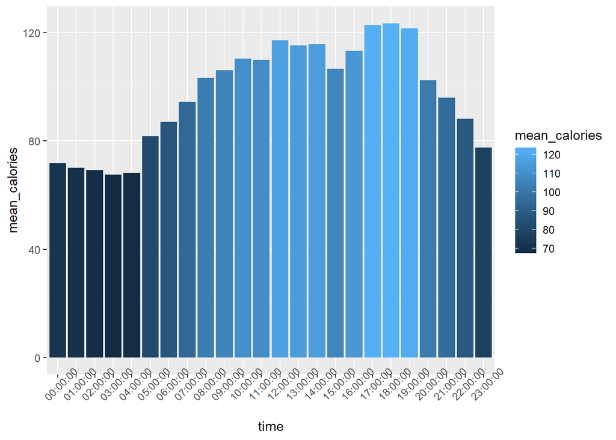

```r
ggplot(data=hourly_mean, aes(x=time, y=mean_calories, fill=mean_calories)) + geom_bar(stat="identity") + theme(axis.text.x = element_text(angle = 45))
```

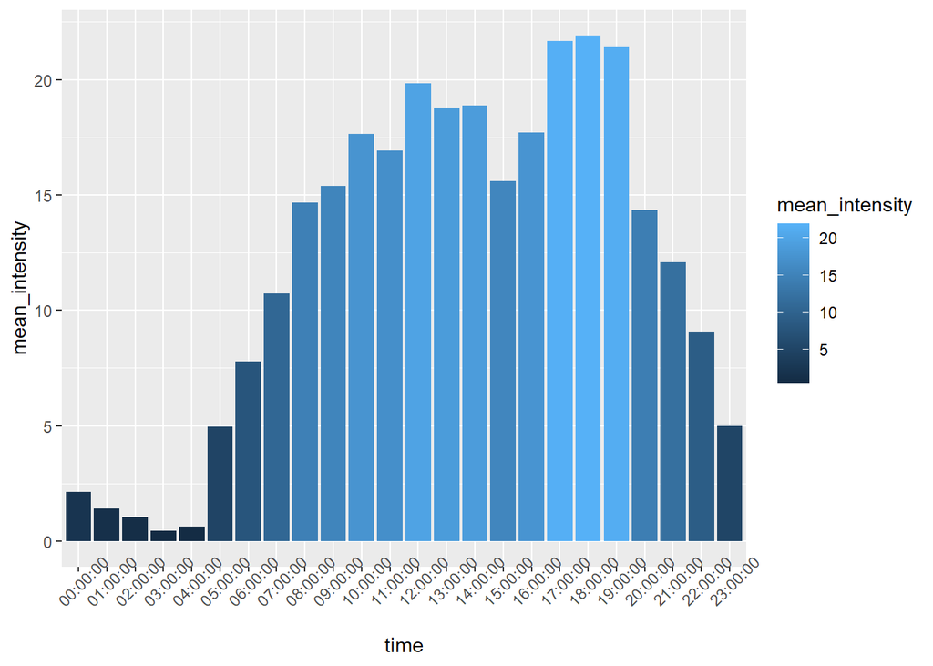

```r
ggplot(data=hourly_mean, aes(x=time, y=mean_intensity, fill=mean_intensity)) + geom_bar(stat="identity") + theme(axis.text.x = element_text(angle = 45))
```

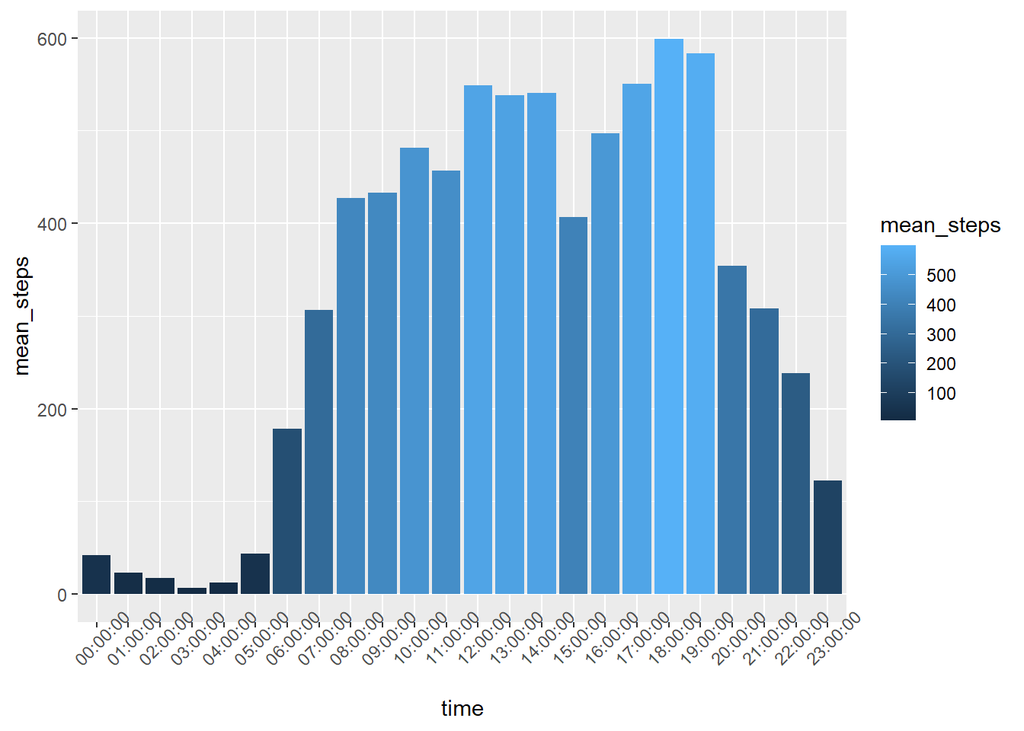

```r
ggplot(data=hourly_mean, aes(x=time, y=mean_steps, fill=mean_steps)) + geom_bar(stat="identity") + theme(axis.text.x = element_text(angle = 45))
```

**Observations:**

- Participants were most active between 16:00-18:59 hours followed by 11:00-13:59 hours.
- As expected, calories were least burnt between 23:00-04:59 hours.

#### Relationship between time in bed and minutes asleep

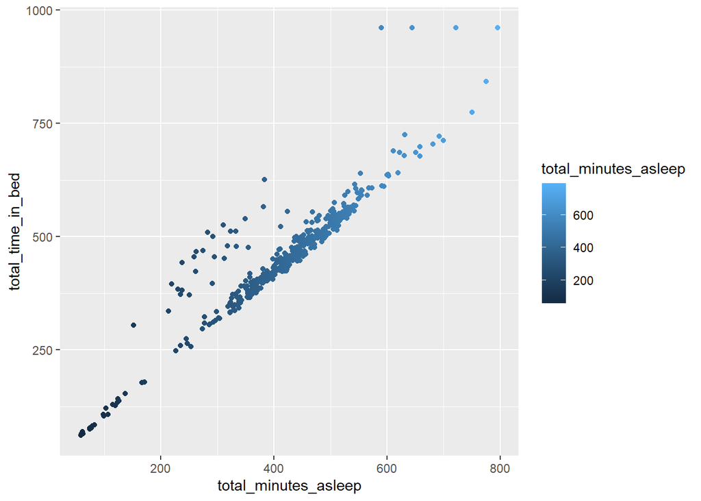

```r
ggplot(data=sleep_day) + geom_point(mapping=aes(x=total_minutes_asleep, y=total_time_in_bed, color=total_minutes_asleep))
```

**Observations:**

- A positive linear relationship is observed between total time in bed and total minutes asleep.
- Furthermore, few participants seem to have spent a lot of time in bed but didn’t asleep. The team could work to focus on sleep or insomnia related apps.
- Out of 33 participants, 24 participants had logged their sleep activity. More marketing content towards sleep tracking features.

#### Trends with weight tracking

**Observations:**

- Only 8 participants logged their weight in the Fitbit app, in contrast to 33 users logging their daily activities.
- Bellabeat’s app could implement push notification services to encourage users to push for increased weight tracking.

## Phase 5 - Share

### 1. Average Distribution of Active Minutes

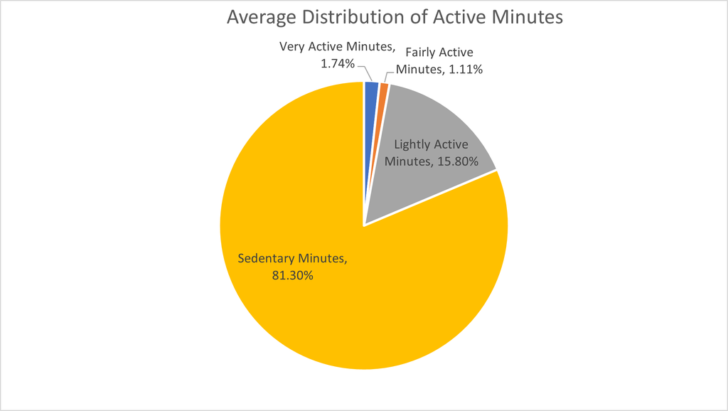

#### Findings:

- Insights indicate most participants used the Fitbit app to track inactive moments such as daily work, commute etc. (approximately 81.3%).
- Marketing could push for campaigns such as small workout sessions between work, or encourage taking small walk breaks between work or leisure hours, such as taking a walk break every 30 minutes, encouraging more users to walk and track their fitness.

### 2. Most Active Times of the Day

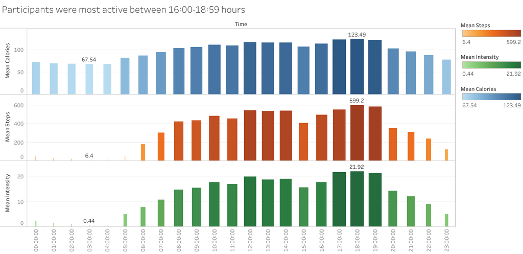

### 3. Sleep Tracking

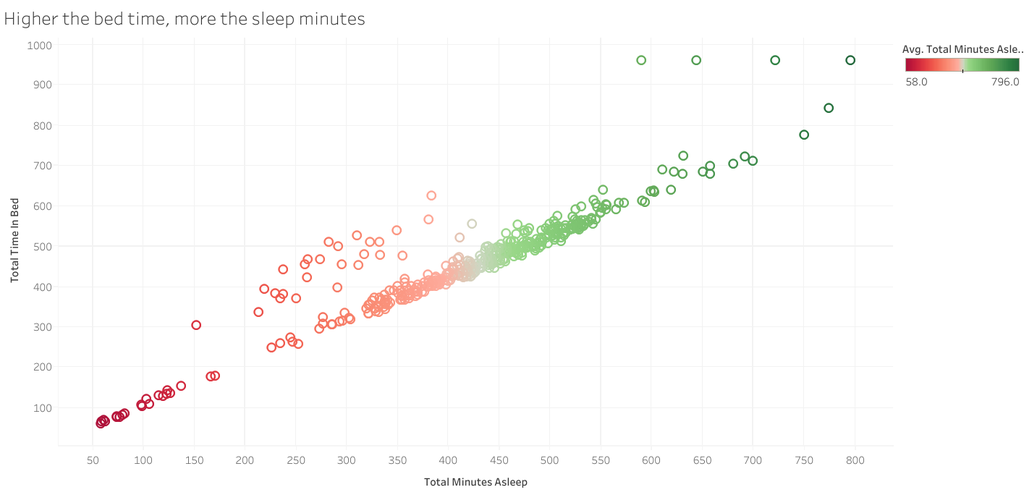

#### Findings:

- As anticipated, the data indicates a strict positive relationship between Total Time in Bed and Total Minutes asleep.
- Furthermore, few participants seem to have spent a lot of time in bed but didn’t asleep. The team could work to focus on sleep or insomnia related apps.
- Out of 33 participants, only 24 participants had logged their sleep activity. Marketing strategies encompassing sleep tracking features and benefits of sleep tracking could be adopted.

### 4. Comparison of Activity Tracking

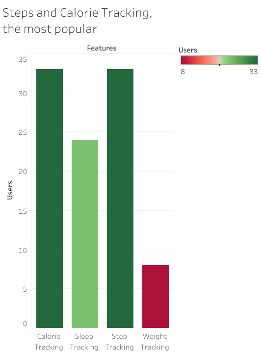

## Phase 6 - Act

### Application of these trends in Bellabeat’s marketing strategy

- Both Fitbit and Bellabeat are engaged in the digital fitness industry. Bellabeat’s products could be used to encourage customers for health tracking by highlighting the benefits of smart-devices.
- Benefits of sleep and weight tracking could be marketed with smart-watches and smart weighing scales, along with benefits of how proper sleep results in burning of calories. Proper sleep = active health.
- Marketing could push for campaigns such as quick workouts between work, or encourage taking small walk breaks between work or leisure hours, such as taking a walk break every 30 minutes, encouraging more users to walk and track their fitness.
- As the app is used to track more than 80% of sedentary activity, marketing campaigns highlighting, ‘Why being seated for long hours is bad for health’ could be strongly pushed.